# Multivariate Modeling Principles

**Where are we?!**  
- You’ve seen *most* of the RStudio syntax we’ll need in this course. You’ll continue to apply and familiarize yourself with this code. - We’re talking about multivariate relationships: modeling y by multiple predictors x! Why? If 2 or more predictors x both tell us about y, then maybe both together can tell us even more! - You’ll explore the main ideas today. The video for tomorrow will *review* these ideas and then you’ll explore these same ideas more deeply on Tuesday and Wednesday.

**Goals**

- **Multivariate statistical models** can enhance our understanding and predictions of a response variable $y$ by including *more than one predictor variable*. [You can find the preparatory slides for this topic here.](https://drive.google.com/file/d/1zBr71v1XqfmQpah1Go22ZMT8sApTcxRS/view?usp=sharing)
- In this activity, we’ll explore multivariate visualizations and models. In doing so, recall that it’s important to focus on the *guiding principles* (good for long-term retention, deeper understanding, and ability to generalize) as opposed memorizing “rules” (which don’t exist!).
- Practice *interpreting* multivariate models.

## Getting started

Load some data:

```r
# Load packages & import data
library(ggplot2)
library(dplyr)
bikes <- read.csv("https://www.macalester.edu/~dshuman1/data/155/bike_share.csv")
```

Take a quick peak at the results for four bivariate models of ridership, which will be referenced throughout the activity:

```r
# Build and summarize some bivariate models
bike_model_1 <- lm(riders_registered ~ windspeed, bikes)
summary(bike_model_1)$r.squared
```

```
## [1] 0.04728406
```

```r
bike_model_2 <- lm(riders_registered ~ temp_feel, bikes)
summary(bike_model_2)$r.squared
```

```
## [1] 0.2961447
```

```r
bike_model_3 <- lm(riders_registered ~ weekend, bikes)
summary(bike_model_3)$r.squared
```

```
## [1] 0.07404211
```

```r
bike_model_4 <- lm(riders_registered ~ season, bikes)
summary(bike_model_4)$r.squared
```

```
## [1] 0.2784603
```

Below, you will consider three more models, each which have **two** predictors. Note the syntax now (you’ll explore the output below).

```r
# A model with 1 categorical & 1 quantitative predictor
bike_model_5 <- lm(riders_registered ~ windspeed + weekend, bikes)
summary(bike_model_5)$r.squared
```

```
## [1] 0.11935
```

```r
# A model with 2 categorical predictors
bike_model_6 <- lm(riders_registered ~ weekend + season, bikes)
summary(bike_model_6)$r.squared
```

```
## [1] 0.3485475
```

```r
# A model with 2 quantitative predictors
bike_model_7 <- lm(riders_registered ~ windspeed + temp_feel, bikes)
summary(bike_model_7)$r.squared
```

```
## [1] 0.3104357
```

## Exercises

### Exercise 1: Hello!

### Exercise 2: 1 categorical & 1 quantitative predictor: visualization

Adjust the code below to recreate this visualization of the relationship of `riders_registered` with the quantitative `windspeed` predictor and categorical `weekend` predictor.

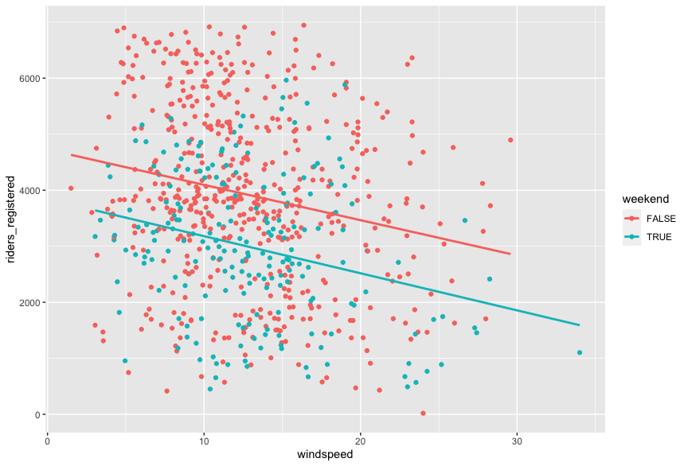

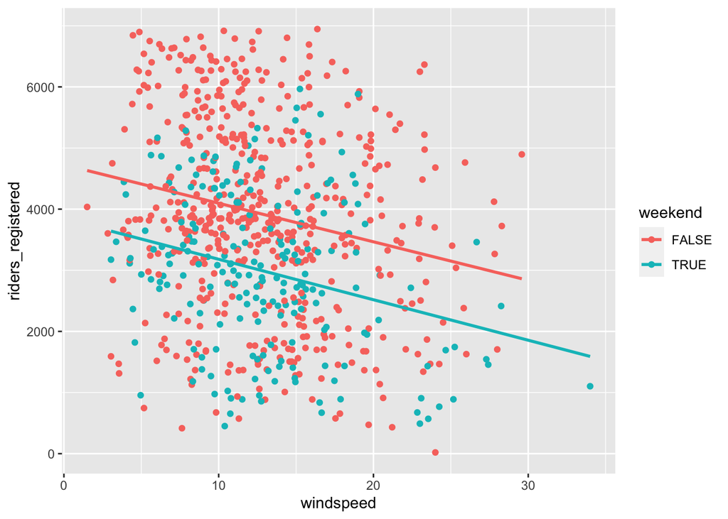

```r
ggplot(bikes, aes(y = riders_registered, x = windspeed, color = weekend)) +
  geom_point() +
  geom_smooth(method = "lm", se = FALSE)
```

### Exercise 3: 1 categorical & 1 quantitative predictor: building a model

`bike_model_5` (which you built above) *models* the multivariate trend of riders vs windspeed and weekend:

```r
summary(bike_model_5)$coefficient
```

```
##               Estimate Std. Error   t value      Pr(>|t|)
## (Intercept) 4738.38053  147.53653 32.116659 1.208405e-141
## windspeed    -63.97072   10.45274 -6.119997  1.528443e-09
## weekendTRUE -925.15701  119.86330 -7.718434  3.891082e-14
```

1. Fill in the model formula: riders_registered = 4738.38053 - 63.97072 windspeed - 925.15701 weekendTRUE
2. Confirm that `bike_model_5` predicts roughly 3174 rides on *weekend* days when the windspeed is 10 mph and roughly 4099 rides on *weekdays* when the windspeed is 10 mph. Make sure you can match up these predictions with what you see on the plot.

```r
4738.38053 - 63.97072 * 10 - 925.15701 * 1
```

```
## [1] 3173.516
```

```r
4738.38053 - 63.97072 * 10 - 925.15701 * 0
```

```
## [1] 4098.673
```

### Exercise 4: 1 categorical & 1 quantitative predictor: interpreting the model

We saw in exercise 2 that the `bike_model_5` trend is represented by two lines: one describing the relationship between rides and windspeed on weekends and the other on weekdays. This observation is key to interpreting `bike_model_5`!

With no wind, on a weekday, there are intercept coeff ridres. Each mph of wind decreases the ridership by 63.97. Weekends have a lower ridership on the average day.

### Exercise 5: 2 categorical predictors: visualization

Adjust the code below to recreate this visualization of the relationship of `riders_registered` with the categorical `season` and `weekend` predictors. HINT: color or fill

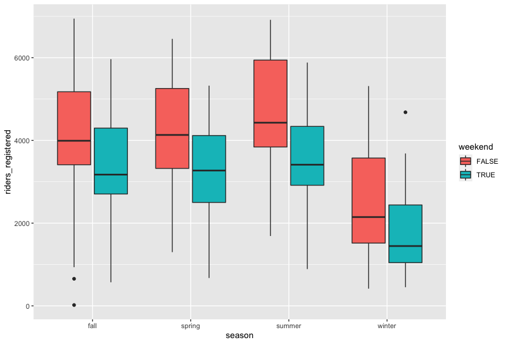

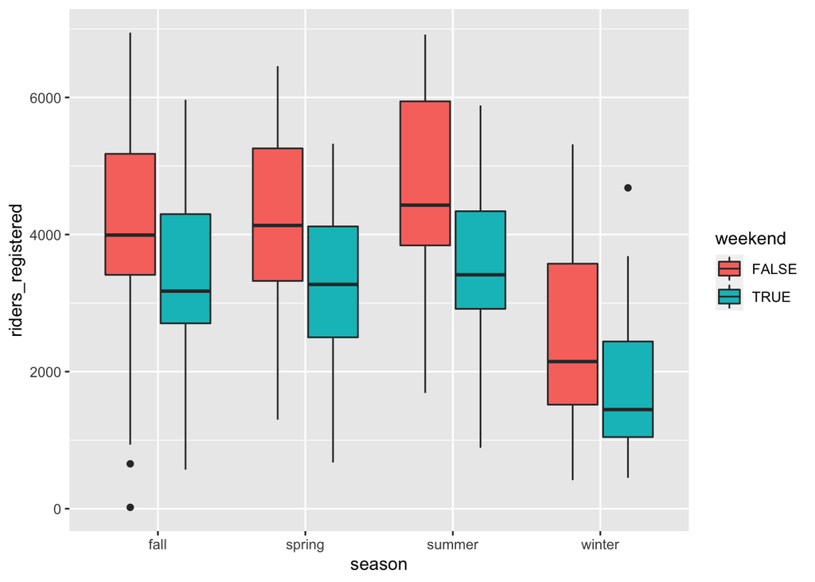

```r
ggplot(bikes, aes(y = riders_registered, x = season, fill = weekend)) +
  geom_boxplot()
```

### Exercise 6: 2 categorical predictors: build & interpret the model

`bike_model_6` (which you built above) *models* the multivariate trend of riders vs season and weekend:

```r
summary(bike_model_6)$coefficient
```

```
##                Estimate Std. Error     t value      Pr(>|t|)
## (Intercept)   4260.4492   99.16363  42.9638294 1.384994e-201
## weekendTRUE   -912.3324  103.23016  -8.8378473  7.298199e-18
## seasonspring  -116.3824  132.76018  -0.8766364  3.809741e-01
## seasonsummer   438.4424  132.06413   3.3199205  9.454177e-04
## seasonwinter -1719.0572  133.30505 -12.8956646  2.081758e-34
```

1. Confirm that the model formula is: `riders_registered = 4260.45 - 912.33 weekendTRUE - 116.38 seasonspring + 438.44 seasonsummer - 1719.06 seasonwinter`
2. Use this model to predict the ridership on the following days:
   - a fall weekday
   - a winter weekday
   - a fall weekend day
   - a winter weekend day

```r
4260.45 - 912.33 * 0 - 116.38 * 0 + 438.44 * 0 - 1719.06 * 0
```

```
## [1] 4260.45
```

```r
4260.45 - 912.33 * 0 - 116.38 * 0 + 438.44 * 0 - 1719.06 * 1
```

```
## [1] 2541.39
```

```r
4260.45 - 912.33 * 1 - 116.38 * 0 + 438.44 * 0 - 1719.06 * 0
```

```
## [1] 3348.12
```

```r
4260.45 - 912.33 * 1 - 116.38 * 0 + 438.44 * 0 - 1719.06 * 1
```

```
## [1] 1629.06
```

3. How many possible predictions does this model produce?

```r
2*4
```

```
## [1] 8
```

4. Use these calculations and insights to interpret the intercept coefficient, `weekendTRUE` coefficient, and `seasonwinter` coefficient. Hint: What is the meaning and consequence of plugging in 0 for `weekendTRUE`? Plugging in 1?

On the weekend, there are roughly 900 less riders, and in the winter there are roughly 1700 even less riders than in fall.

### Exercise 7: 2 quantitative predictors: visualization

Adjust the code below to recreate two visualizations of the relationship of `riders_registered` with the quantitative `windspeed` and `temp_feel` predictors.

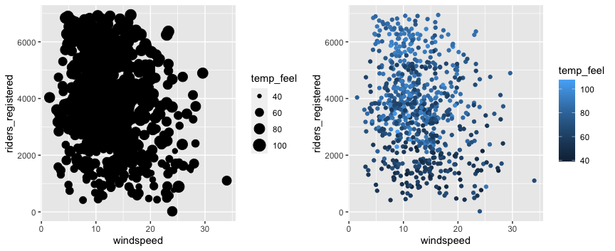

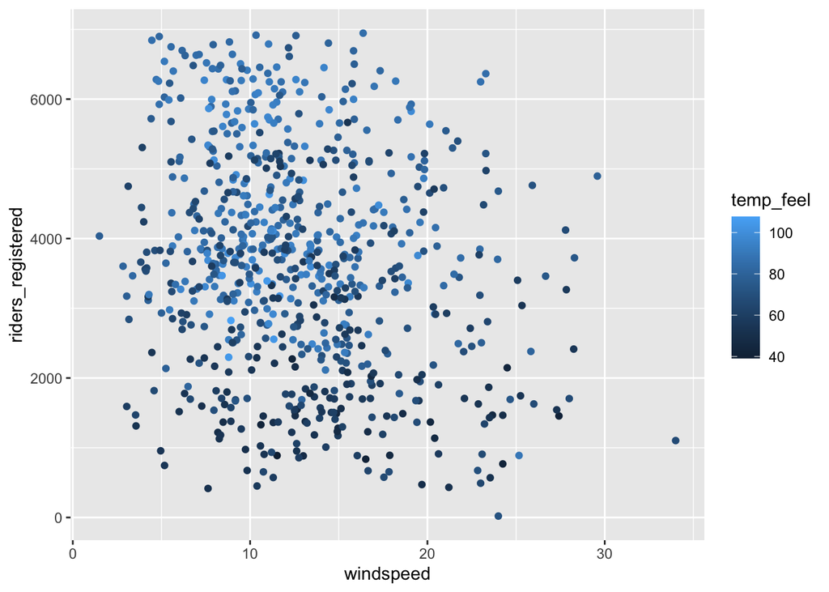

```r
ggplot(bikes, aes(y = riders_registered, x = windspeed, color = temp_feel)) +
  geom_point()
```

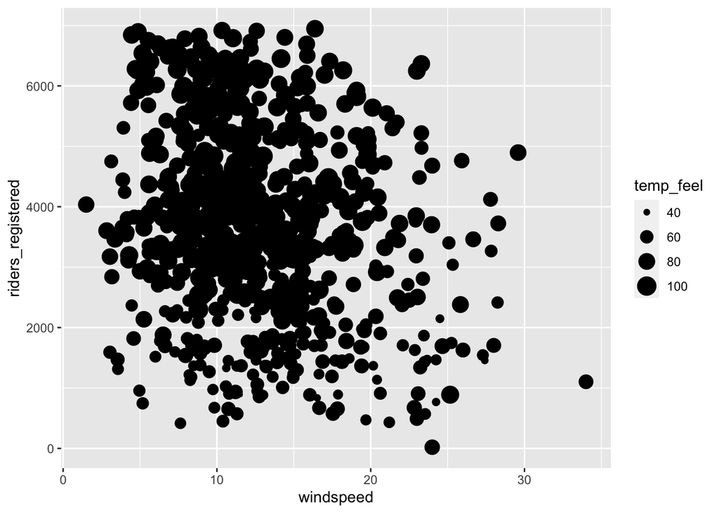

```r
ggplot(bikes, aes(y = riders_registered, x = windspeed, size = temp_feel)) +
  geom_point()
```

### Exercise 8: 2 quantitative predictors: modeling

`bike_model_7` (which you built above) *models* the multivariate trend of riders vs windspeed and temperature:

```r
summary(bike_model_7)$coefficient
```

```
##              Estimate Std. Error     t value     Pr(>|t|)
## (Intercept) -24.06464 299.303032 -0.08040225 9.359394e-01
## windspeed   -36.54372   9.408116 -3.88427585 1.119805e-04
## temp_feel    55.51648   3.330739 16.66791759 4.436963e-53
```

1. Write out the model formula.

riders = -24.0646 - 36.54372 * windspeed + 55.51648 * temp_feel

2. Confirm that this model predicts roughly 2941 rides on days when the windspeed is 10 mph and the temperature is 60 degrees.

```r
-24.0646 - 36.54372 * 10 + 55.51648 * 60
```

```
## [1] 2941.487
```

### Exercise 9: 2 quantitative predictors: interpreting the model

- In the left plot, the red arrows demonstrate the model trend at three different windspeeds (5, 20, and 30 mph). What are the slopes of these lines?

$$55.51648$$

- In the right plot, the red arrows demonstrate the model trend at three different temperatures (40, 60, and 90 degrees). What are the slopes of these lines?

$$-36.54372$$

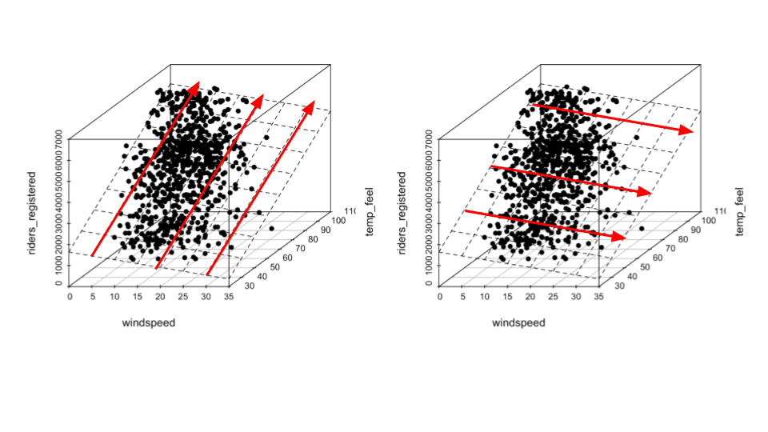

### Exercise 10: Which is best?

We’ve now seen 7 different models of ridership. Use the following table to answer the questions below.

| model | predictors | R<sup>2</sup> |
| --- | --- | --- |
| `bike_model_1` | `windspeed` | 0.047 |
| `bike_model_2` | `temp_feel` | 0.296 |
| `bike_model_3` | `weekend` | 0.074 |
| `bike_model_4` | `season` | 0.279 |
| `bike_model_5` | `windspeed` & `weekend` | 0.119 |
| `bike_model_6` | `weekend` & `season` | 0.349 |
| `bike_model_7` | `windspeed` & `temp_feel` | 0.310 |

1. Which model does the best job of explaining the variability in ridership from day to day? What does this tell you about ridership?

model6, riders ~ weekend + season

2. If you could only pick one predictor, which would it be?

temp_feel

3. What happens to R-squared when we add a second predictor to our model, and why does this make sense? For example, how does the R-squared for model 5 (with both windspeed and weekend) compare to those of model 1 (only windspeed) and model 3 (only weekend)?

It generally increases, which makes sense because riders choose to ride for many reasons. Model 5 has an r squared value of almost the sum of models 3 and 1.

4. Are 2 predictors always better than 1? Provide evidence and explain why this makes sense.

No, temp_feel by itself was a better match than windspeed and weekend. This makes sense because certain factors weigh more heavily than others, or even combinations of others.

### Exercise 11: Reflection: principles of interpretation

These exercises have revealed some **principles** behind interpreting model coefficients. These are summarized below. Review and confirm that these make sense.

**Principles of interpretation**

A linear regression model describes the **trend** of a relationship between a *response* variable ($y$) and a set of *predictors* ($x_1, x_2, ..., x_p$). Suppose we have the following model *without* interaction terms (which we’ll learn about soon):

$$y = \beta_0 + \beta_1 x_1 + \beta_2 x_2 + \cdots + \beta_p x_p$$

Then we can interpret the coefficients as follows:

- $\beta_0$ (“beta 0”) is the y-intercept. It describes the typical value of $y$ when $x_1, x_2,..., x_k$ are all 0, ie. when all quantitative predictors are set to 0 and the categorical predictors are set to their reference levels.
- $\beta_i$ (“beta i”) is the coefficient of $x_i$.
  - If $x_i$ is quantitative, $\beta_i$ describes the typical change in $y$ per 1-unit increase in $x_i$ while at a fixed set of the other $x$.
  - If $x_i$ represents a category of a categorical variable, $\beta_i$ describes the typical change in $y$ when we move to this category from the reference category while at a fixed set of the other $x$.

## Optional: extra practice

NOTE: The video for tomorrow will go through practice exercises 1 through 4.

### Exercise 12: Curiosity!

In working through the exercises, you probably had an “I wonder…” moment or two. What were they? What else do you want to learn about these data? Try it!

### Exercise 13: Practice 1

Consider the relationship of `riders_registered` vs `weekend` and `weather_cat`.  
a. Construct a visualization of this relationship.  
b. Construct a model of this relationship.  
c. Interpret the first 3 model coefficients.

### Exercise 14: Practice 2

Consider the relationship of `riders_registered` vs `temp_feel` and `humidity`.  
a. Construct a visualization of this relationship.  
b. Construct a model of this relationship.  
c. Interpret the first 3 model coefficients.

### Exercise 15: Practice 3

Consider the relationship of `riders_registered` vs `temp_feel` and `weather_cat`.

1. Construct a visualization of this relationship.
2. Construct a model of this relationship.
3. Interpret the first 3 model coefficients.

### Exercise 16: Practice 4: CHALLENGE

We’ve looked at models with 2 predictors. What about 3 predictors?! Consider the relationship of `riders_registered` vs `temp_feel`, `humidity`, AND `weekend`. a. Construct a visualization of this relationship.  
b. Construct a model of this relationship.  
c. Interpret each model coefficient.  
d. If you had to *draw* the shape of the model trend, what would it look like: a line, parallel lines, a plane, parallel planes?